# PA1_template.Rmd

owilks

March 30, 2016

## Retrieving the Data

First step was to retrieve the data from the coursepage at: https://www.coursera.org/learn/reproducible-research/peer/gYyPt/course-project-1 and then download and store the data into a table using the following code.

```r
library(chron)
download.file("http://d396qusza40orc.cloudfront.net/repdata%2Fdata%2Factivity.zip","c5_a1.zip")
unzip("c5_a1.zip")

data <- read.csv("activity.csv")
```

## What is the mean total number of steps taken per day

*1. Calculate the total number of steps taken per day*

To do this we use the aggregate function to collapse the data based on a function and a variable. Similar to the “GROUP BY” function in SQL. Applying sum on the entire list based on steps and grouped by date.

```r
his1 <- aggregate(data$steps, by=list(date=data$date), FUN=sum, na.rm=TRUE)
```

*2. Make a histogram of the total number of steps taken each day*

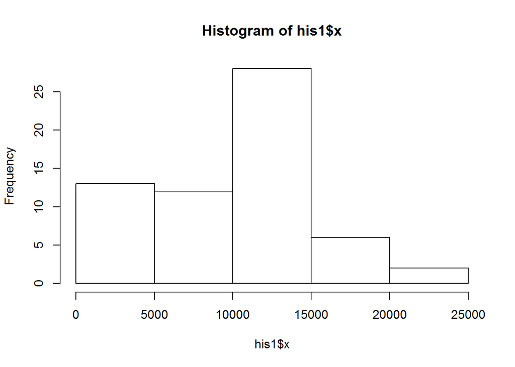

```r
hist(his1$x)
```

The mean number of steps taken per day is 9354

## What is the average daily activity pattern?

*1. Make a time series plot (i.e. type = “l”) of the 5-minute interval (x-axis) and the average number of steps taken, averaged across all days (y-axis)*

Using the same strategy as before, the aggregation was done instead on the “interval” column and the “steps” column.

The function used instead of “sum” this time was “mean” to effectively calculate the requested mean.

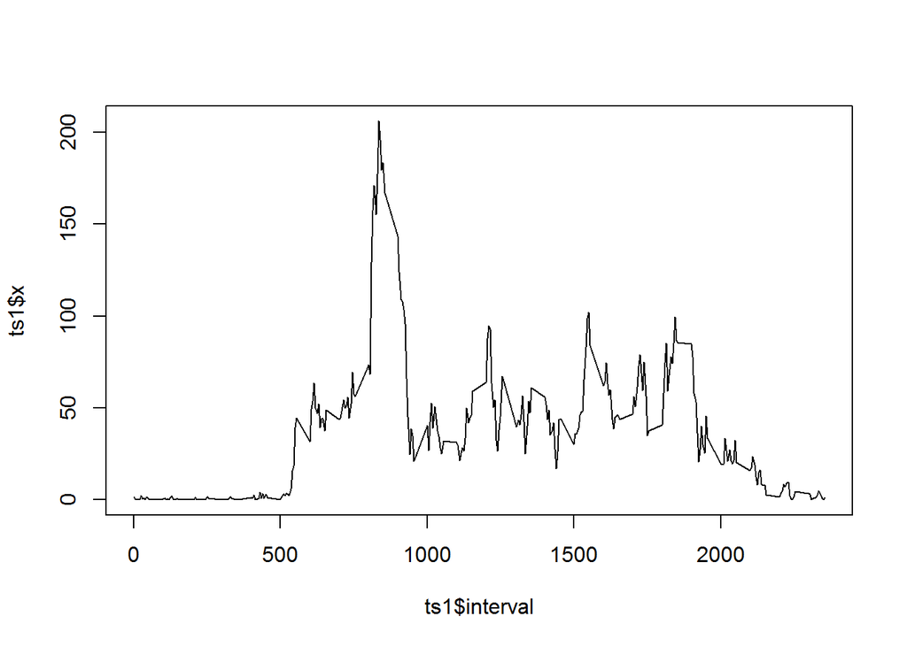

```r
ts1 <- aggregate(data$steps, by=list(interval=data$interval), FUN=mean, na.rm=TRUE)

#Instead of using the ts function we directly use the plot function since the
#given list has the x and y values and the instructions indicated the "l" type

plot(ts1$interval,ts1$x,type="l")
```

*2. Which 5-minute interval, on average across all the days in the dataset, contains the maximum number of steps?*

The first step was finding out which point in the list had the maximum value for steps, which was accomplished using the **which.max** function to get a value of 104.

The 5-min interval with the maximum number of steps was **ts1$interval[104]** or 835